# Worksheet 2 - Net migration barchart

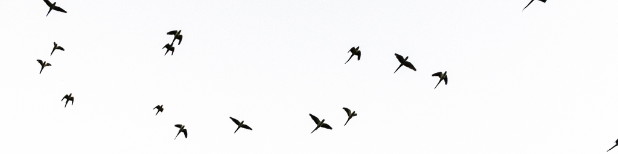

**Dataset**

This worksheet’s dataset is modified from one found at the [World Bank](https://datacatalog.worldbank.org/search/dataset/0037655/Population-Estimates-and-Projections).

↓ Click the link below to download the dataset for this worksheet to your hard drive.

migration.csv

**Final plot**

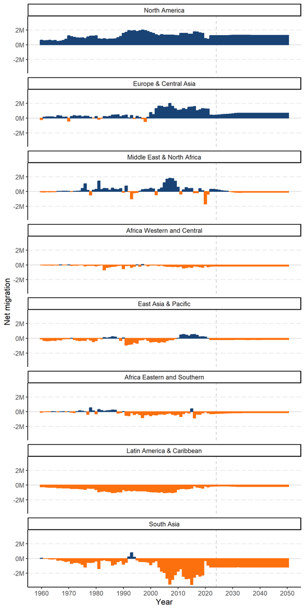

# 1 Step-by-step

## 1.1 Read in data from csv

Instead of `readxl::read_xlsx` we’ll use the `read_csv` function from the `readr` package.

```r
data_raw <-
  readr::read_csv(file = "migration.csv")
```

## 1.2 Make a basic barchart

Use `ggplot` and a `geom_col` to make a bar chart. Then use `aes` to map the x and y axes to the year and net migration columns. Don’t forget the backticks around column names that have spaces in them!

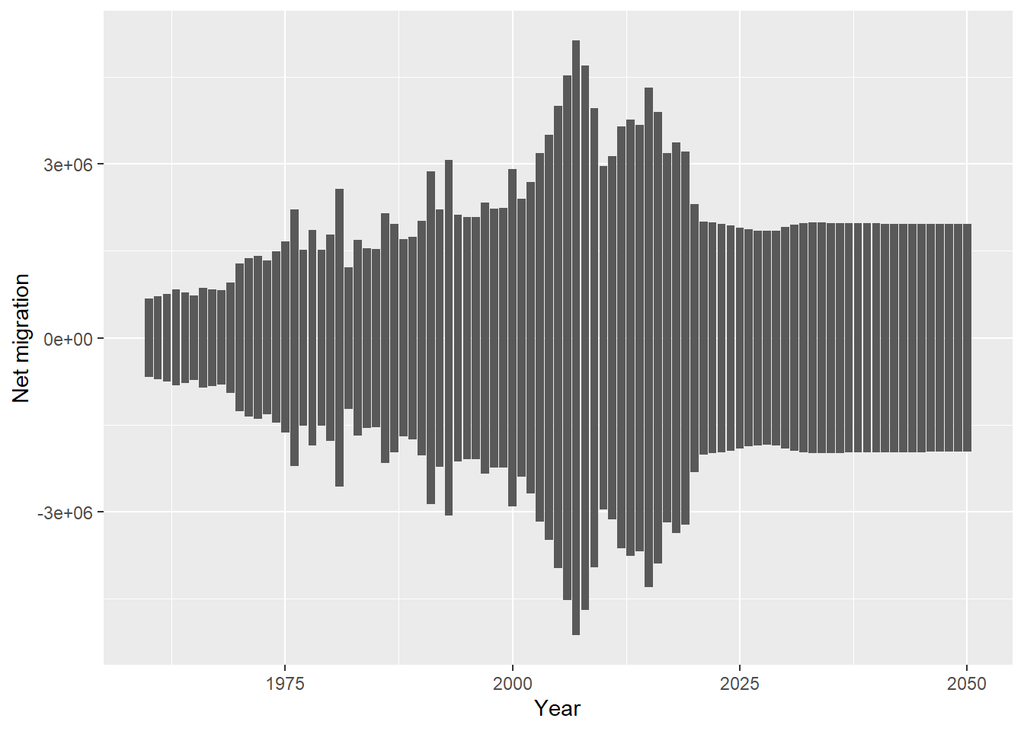

```r
data_raw |>
  ggplot2::ggplot() +
  ggplot2::geom_col(mapping = ggplot2::aes(x = Year,
                                           y = `Net migration`))
```

## 1.3 Add a theme

Add an out-of-the-box ggplot2 theme like `theme_classic` to make the plot look a bit nicer.

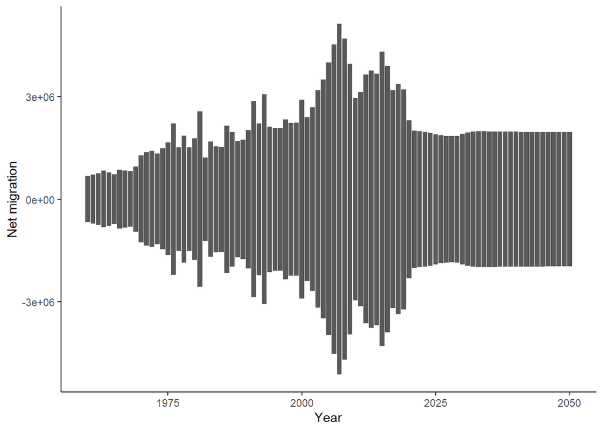

```r
data_raw |>
  ggplot2::ggplot() +
  ggplot2::geom_col(mapping = ggplot2::aes(x = Year,
                                           y = `Net migration`)) +
  ggplot2::theme_classic()
```

## 1.4 Add a facet

Add a `facet_wrap` to make a small plot for every unique value in the country name column (I know they’re not really countries!). I’ve constrained it to only use one column with the ‘ncol’ argument.

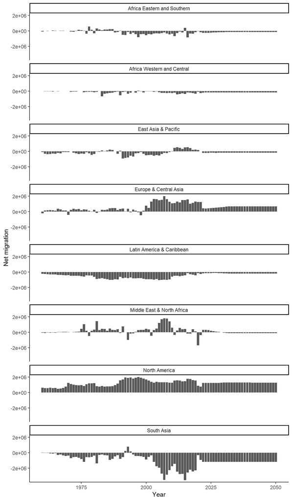

```r
data_raw |>
  ggplot2::ggplot() +
  ggplot2::geom_col(mapping = ggplot2::aes(x = Year,
                                           y = `Net migration`)) +
  ggplot2::facet_wrap(facets = ggplot2::vars(`Country Name`),
                      ncol = 1) +
  ggplot2::theme_classic()
```

## 1.5 Fix the x axis breaks

Add a `scale_x_continuous` and modify the ‘breaks’ argument to force them to be a different width.

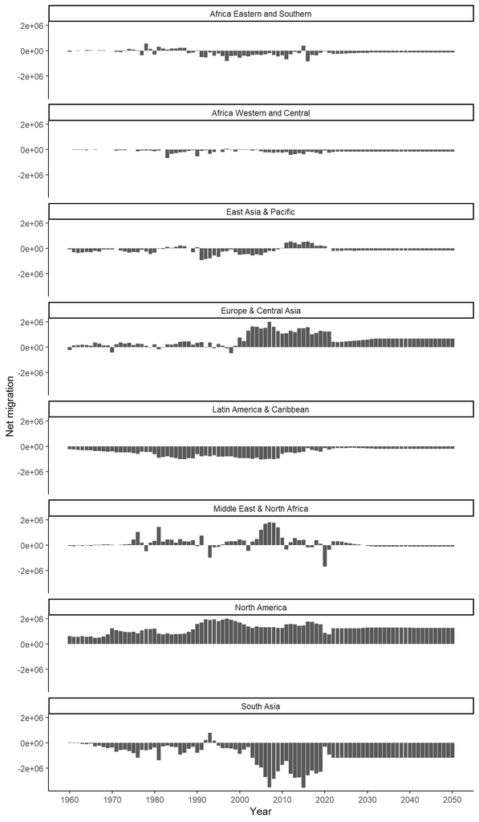

```r
data_raw |>
  ggplot2::ggplot() +
  ggplot2::geom_col(mapping = ggplot2::aes(x = Year,
                                           y = `Net migration`)) +
  ggplot2::scale_x_continuous(breaks = scales::breaks_width(10)) +
  ggplot2::facet_wrap(facets = ggplot2::vars(`Country Name`),
                      ncol = 1) +
  ggplot2::theme_classic()
```

## 1.6 Fix the y axis labels

Add a `scale_y_continuous` and modify the ‘labels’ argument change e.g. 2e+06 (equal to 2 million) to 2M.

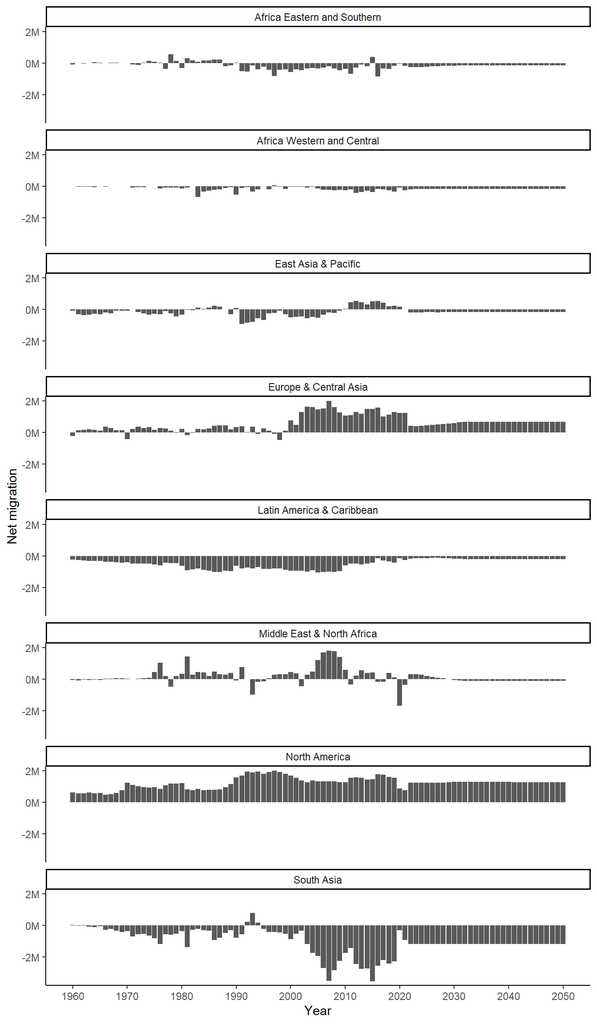

```r
data_raw |>
  ggplot2::ggplot() +
  ggplot2::geom_col(mapping = ggplot2::aes(x = Year,
                                           y = `Net migration`)) +
  ggplot2::scale_x_continuous(breaks = scales::breaks_width(10)) +
  ggplot2::scale_y_continuous(labels = scales::label_comma(scale = 1*10^-6,
                                                           suffix = "M")) +
  ggplot2::facet_wrap(facets = ggplot2::vars(`Country Name`),
                      ncol = 1) +
  ggplot2::theme_classic()
```

## 1.7 Fill the bars depending on +/-

Add a ‘fill’ argument to `aes` and set it to `ggplot2::after_stat(y > 0)`. This fill the bars differently depending on whether they are above or below zero on the y axis.

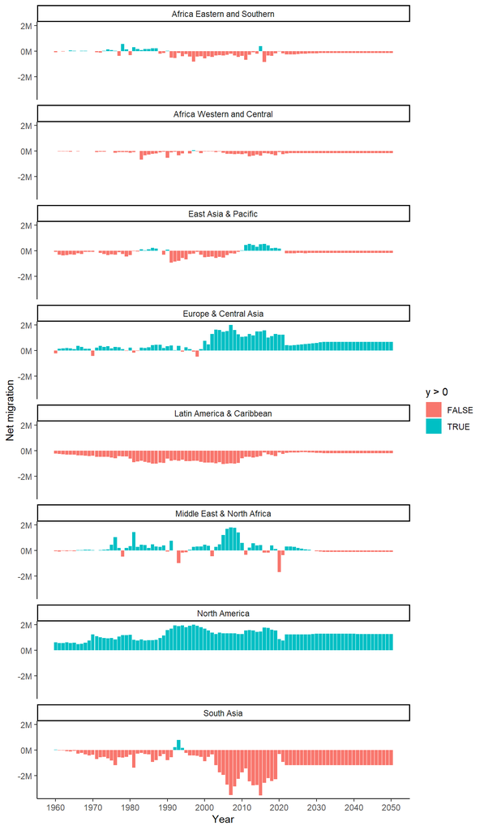

```r
data_raw |>
  ggplot2::ggplot() +
  ggplot2::geom_col(mapping = ggplot2::aes(x = Year,
                                           y = `Net migration`,
                                           fill = ggplot2::after_stat(y > 0))) +
  ggplot2::scale_x_continuous(breaks = scales::breaks_width(10)) +
  ggplot2::scale_y_continuous(labels = scales::label_comma(scale = 1*10^-6,
                                                           suffix = "M")) +
  ggplot2::facet_wrap(facets = ggplot2::vars(`Country Name`),
                      ncol = 1) +
  ggplot2::theme_classic()
```

## 1.8 Customise the palette

Customise the palette for your new fill aesthetic by adding a `scale_fill_manual` and specifying the ‘values’ argument. The fill aesthetic created by the `after_stat` function has the values `TRUE` or `FALSE` depending on whether it’s above or below zero on the y axis.

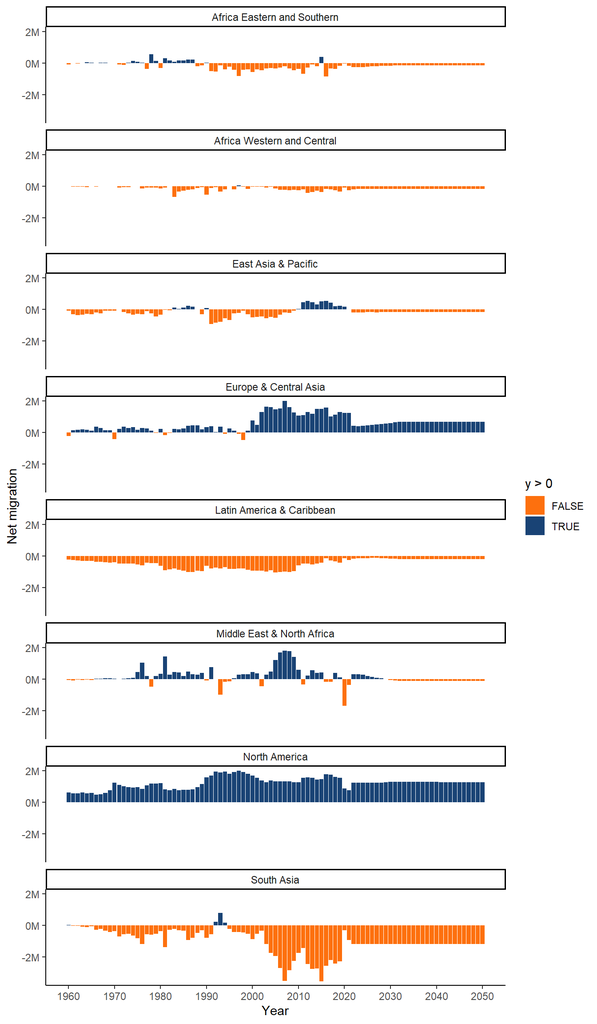

```r
data_raw |>
  ggplot2::ggplot() +
  ggplot2::geom_col(mapping = ggplot2::aes(x = Year,
                                           y = `Net migration`,
                                           fill = ggplot2::after_stat(y > 0))) +
  ggplot2::scale_x_continuous(breaks = scales::breaks_width(10)) +
  ggplot2::scale_y_continuous(labels = scales::label_comma(scale = 1*10^-6,
                                                           suffix = "M")) +
  ggplot2::scale_fill_manual(values = c("TRUE" = "#194375", "FALSE" = "#FD700E")) +
  ggplot2::facet_wrap(facets = ggplot2::vars(`Country Name`),
                      ncol = 1) +
  ggplot2::theme_classic()
```

## 1.9 Remove the legend

Add a `theme` function, after your out-of-the-box theme, and specify the ‘legend.position’ argument as “none”.

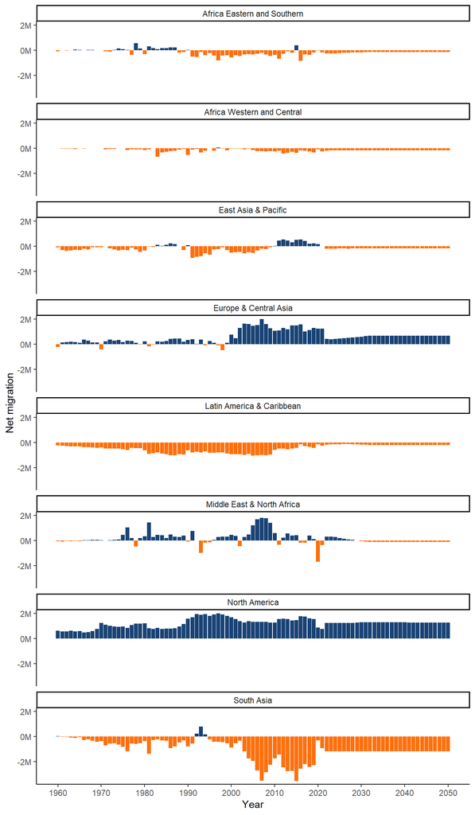

```r
data_raw |>
  ggplot2::ggplot() +
  ggplot2::geom_col(mapping = ggplot2::aes(x = Year,
                                           y = `Net migration`,
                                           fill = ggplot2::after_stat(y > 0))) +
  ggplot2::scale_x_continuous(breaks = scales::breaks_width(10)) +
  ggplot2::scale_y_continuous(labels = scales::label_comma(scale = 1*10^-6,
                                                           suffix = "M")) +
  ggplot2::scale_fill_manual(values = c("TRUE" = "#194375", "FALSE" = "#FD700E")) +
  ggplot2::facet_wrap(facets = ggplot2::vars(`Country Name`),
                      ncol = 1) +
  ggplot2::theme_classic() +
  ggplot2::theme(legend.position = "none")
```

## 1.10 Add some horizontal lines

Add three `geom_hline` functions (hline means horizontal line) before the `geom_col`. Specify the ‘yintercept’ argument for each so that we get lines at -2M, 0, and +2M.

I’ve also specified the ‘colour’ for each as ‘lightgrey’, the ‘linetype’ as “longdash” for two, and the ‘alpha’ (transparency) as either 0.5 or 0.75.

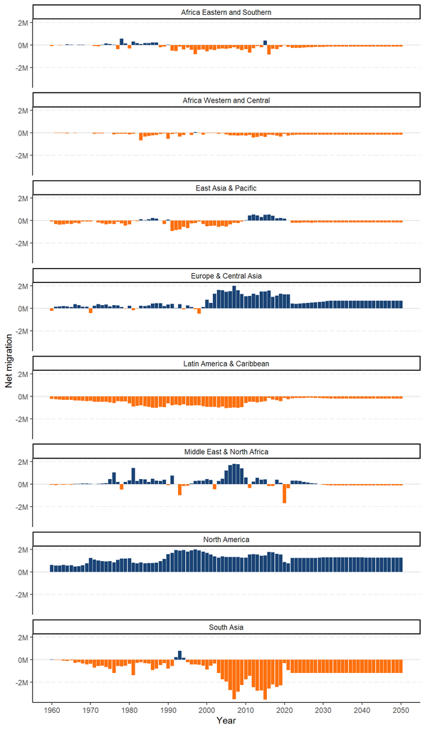

```r
data_raw |>
  ggplot2::ggplot() +
  ggplot2::geom_hline(yintercept = 0,
                      colour = "lightgrey",
                      alpha = 0.75) +
  ggplot2::geom_hline(yintercept = 2*10^6,
                      colour = "lightgrey",
                      linetype = "longdash",
                      alpha = 0.5) +
  ggplot2::geom_hline(yintercept = -2*10^6,
                      colour = "lightgrey",
                      linetype = "longdash",
                      alpha = 0.5) +
  ggplot2::geom_col(mapping = ggplot2::aes(x = Year,
                                           y = `Net migration`,
                                           fill = ggplot2::after_stat(y > 0))) +
  ggplot2::scale_x_continuous(breaks = scales::breaks_width(10)) +
  ggplot2::scale_y_continuous(labels = scales::label_comma(scale = 1*10^-6,
                                                           suffix = "M")) +
  ggplot2::scale_fill_manual(values = c("TRUE" = "#194375", "FALSE" = "#FD700E")) +
  ggplot2::facet_wrap(facets = ggplot2::vars(`Country Name`),
                      ncol = 1) +
  ggplot2::theme_classic() +
  ggplot2::theme(legend.position = "none")
```

## 1.11 Add a vertical line

I’ve also specified the ‘colour’, ‘linetype’, and ‘alpha’ arguments, just like for the horizontal lines.

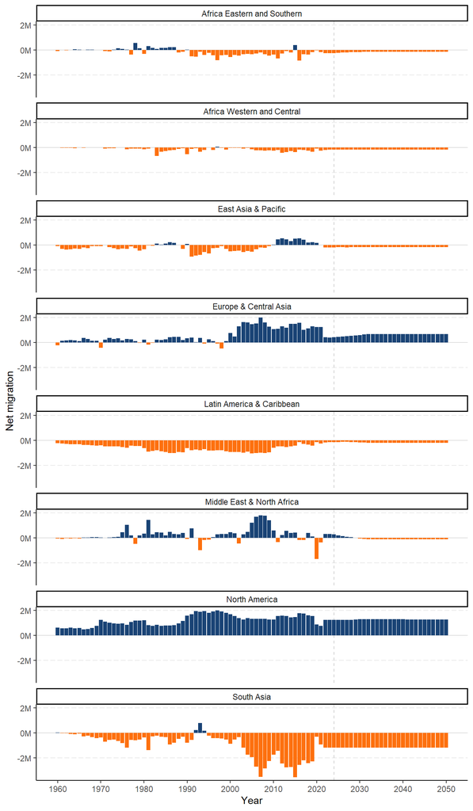

```r
data_raw |>
  ggplot2::ggplot() +
  ggplot2::geom_hline(yintercept = 0,
                      colour = "lightgrey",
                      alpha = 0.75) +
  ggplot2::geom_hline(yintercept = 2*10^6,
                      colour = "lightgrey",
                      linetype = "longdash",
                      alpha = 0.5) +
  ggplot2::geom_hline(yintercept = -2*10^6,
                      colour = "lightgrey",
                      linetype = "longdash",
                      alpha = 0.5) +
  ggplot2::geom_vline(xintercept = 2024,
                      colour = "grey",
                      linetype = "dashed",
                      alpha = 0.75) +
  ggplot2::geom_col(mapping = ggplot2::aes(x = Year,
                                           y = `Net migration`,
                                           fill = ggplot2::after_stat(y > 0))) +
  ggplot2::scale_x_continuous(breaks = scales::breaks_width(10)) +
  ggplot2::scale_y_continuous(labels = scales::label_comma(scale = 1*10^-6,
                                                           suffix = "M")) +
  ggplot2::scale_fill_manual(values = c("TRUE" = "#194375", "FALSE" = "#FD700E")) +
  ggplot2::facet_wrap(facets = ggplot2::vars(`Country Name`),
                      ncol = 1) +
  ggplot2::theme_classic() +
  ggplot2::theme(legend.position = "none")
```

## 1.12 Fix y axis range

We want to set the y axis so there is an equal distance (e.g. 2.5M) above zero as there is below - making it more symmetrical, and perhaps easier to see the overall pattern.

First, before the plot statement, make another statement to create an object which will contain the maximum absolute value of the y axis.

Absolute means you are not interested in the negative or positive sign of each number. So for these numbers (-1000, 0, 900), the maximum absolute value would be 1000.

Use the `max` and `abs` functions to find the maximum absolute value in the net migration column and save it into your new object. Don’t forget to set the ‘na.rm’ argument of `max` to `TRUE` in case there are NA values.

Then use this new object to set the ‘limits’ argument of the `scale_y_continuous` function you made earlier.

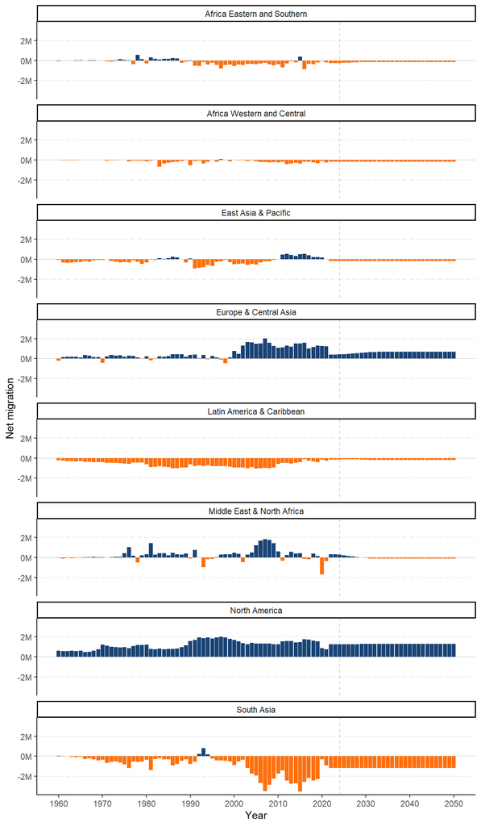

```r
max_y_axis <-
  max(abs(data_raw$`Net migration`), na.rm = TRUE)

data_raw |>
  ggplot2::ggplot() +
  ggplot2::geom_hline(yintercept = 0,
                      colour = "lightgrey",
                      alpha = 0.75) +
  ggplot2::geom_hline(yintercept = 2*10^6,
                      colour = "lightgrey",
                      linetype = "longdash",
                      alpha = 0.5) +
  ggplot2::geom_hline(yintercept = -2*10^6,
                      colour = "lightgrey",
                      linetype = "longdash",
                      alpha = 0.5) +
  ggplot2::geom_vline(xintercept = 2024,
                      colour = "grey",
                      linetype = "dashed",
                      alpha = 0.75) +
  ggplot2::geom_col(mapping = ggplot2::aes(x = Year,
                                           y = `Net migration`,
                                           fill = ggplot2::after_stat(y > 0))) +
  ggplot2::scale_x_continuous(breaks = scales::breaks_width(10)) +
  ggplot2::scale_y_continuous(labels = scales::label_comma(scale = 1*10^-6,
                                                           suffix = "M"),
                              limits = c(-max_y_axis, max_y_axis)) +
  ggplot2::scale_fill_manual(values = c("TRUE" = "#194375", "FALSE" = "#FD700E")) +
  ggplot2::facet_wrap(facets = ggplot2::vars(`Country Name`),
                      ncol = 1) +
  ggplot2::theme_classic() +
  ggplot2::theme(legend.position = "none")
```

## 1.13 Change column border colours

Sometimes columns can look a bit funny with a white border. We’ve changed the fill, but let’s change the border colour as well.

Replicate everything you did to change the fill aesthetic and change the colour aesthetic as well. You’ll need to make changes inside `aes` and you’ll need to add a `scale_colour_manual` to replicate the `scale_fill_manual`.

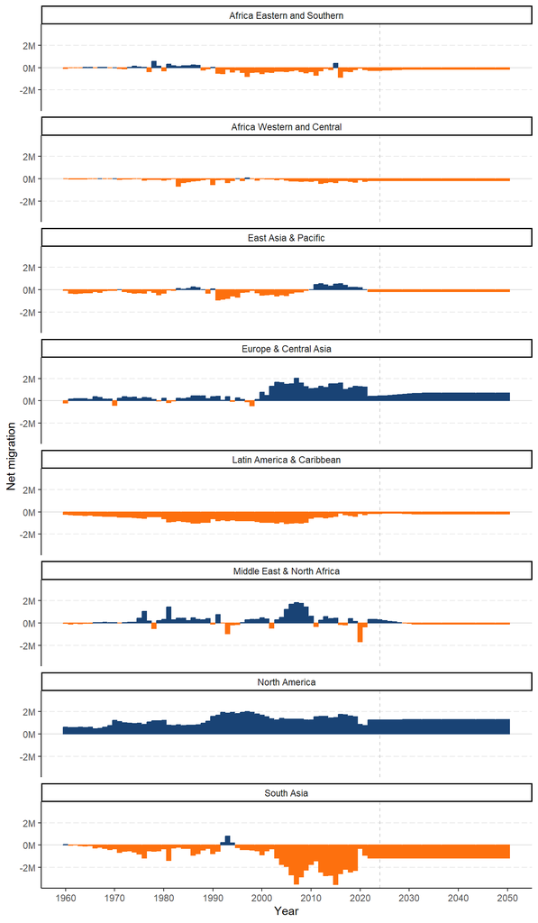

```r
max_y_axis <-
  max(abs(data_raw$`Net migration`), na.rm = TRUE)

data_raw |>
  ggplot2::ggplot() +
  ggplot2::geom_hline(yintercept = 0,
                      colour = "lightgrey",
                      alpha = 0.75) +
  ggplot2::geom_hline(yintercept = 2*10^6,
                      colour = "lightgrey",
                      linetype = "longdash",
                      alpha = 0.5) +
  ggplot2::geom_hline(yintercept = -2*10^6,
                      colour = "lightgrey",
                      linetype = "longdash",
                      alpha = 0.5) +
  ggplot2::geom_vline(xintercept = 2024,
                      colour = "grey",
                      linetype = "dashed",
                      alpha = 0.75) +
  ggplot2::geom_col(mapping = ggplot2::aes(x = Year,
                                           y = `Net migration`,
                                           fill = ggplot2::after_stat(y > 0),
                                           colour = ggplot2::after_stat(y > 0))) +
  ggplot2::scale_x_continuous(breaks = scales::breaks_width(10)) +
  ggplot2::scale_y_continuous(labels = scales::label_comma(scale = 1*10^-6,
                                                           suffix = "M"),
                              limits = c(-max_y_axis, max_y_axis)) +
  ggplot2::scale_fill_manual(values = c("TRUE" = "#194375", "FALSE" = "#FD700E")) +
  ggplot2::scale_colour_manual(values = c("TRUE" = "#194375", "FALSE" = "#FD700E")) +
  ggplot2::facet_wrap(facets = ggplot2::vars(`Country Name`),
                      ncol = 1) +
  ggplot2::theme_classic() +
  ggplot2::theme(legend.position = "none")
```

## 1.14 Reorder your facets

To rearrange the facets in order of total net migration we need to use a `mutate` function from the `dplyr` package. This can modify the country name column (because that’s the one used to facet the plot) in the data before passing it to the plot. We can add this `mutate` on the line right before the first `ggplot` function.

Use the `fct_reorder` function from the `forcats` package (an anagram of factors!) inside the `mutate` function. You’ll need to specify several arguments for `fct_reorder` including ‘.f’, ‘.x’, ‘.fun’, and ‘.desc’ to get it looking just like the one below.

Now we have the area with the most positive all-time total net migration at the top, and the one with the most negative at the bottom.

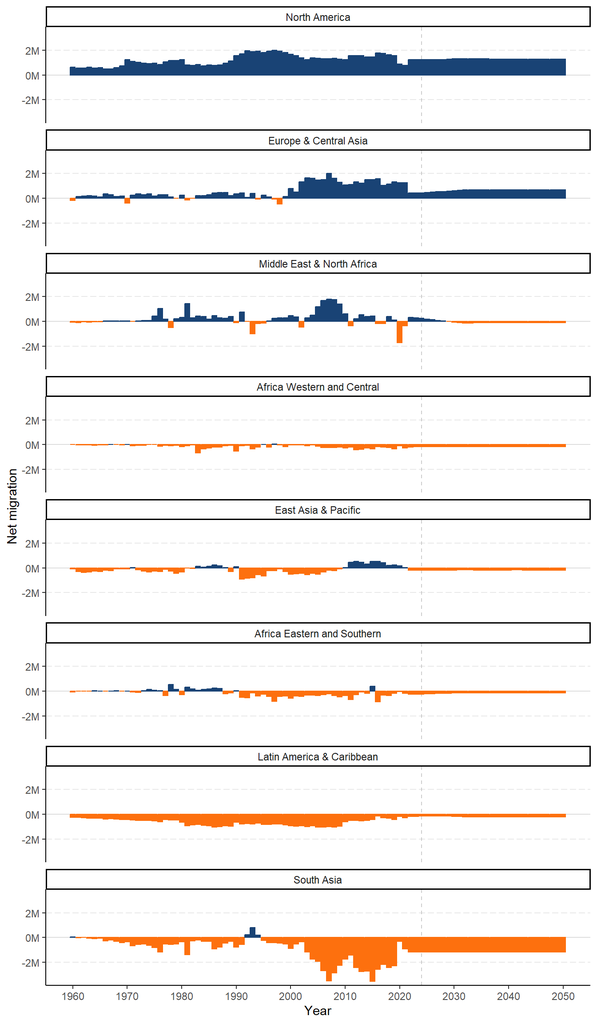

```r
max_y_axis <-
  max(abs(data_raw$`Net migration`), na.rm = TRUE)

data_raw |>
  dplyr::mutate(`Country Name` = forcats::fct_reorder(`Country Name`,
                                                      `Net migration`,
                                                      .fun = sum,
                                                      .desc = TRUE)) |>
  ggplot2::ggplot() +
  ggplot2::geom_hline(yintercept = 0,
                      colour = "lightgrey",
                      alpha = 0.75) +
  ggplot2::geom_hline(yintercept = 2*10^6,
                      colour = "lightgrey",
                      linetype = "longdash",
                      alpha = 0.5) +
  ggplot2::geom_hline(yintercept = -2*10^6,
                      colour = "lightgrey",
                      linetype = "longdash",
                      alpha = 0.5) +
  ggplot2::geom_vline(xintercept = 2024,
                      colour = "grey",
                      linetype = "dashed",
                      alpha = 0.75) +
  ggplot2::geom_col(mapping = ggplot2::aes(x = Year,
                                           y = `Net migration`,
                                           fill = ggplot2::after_stat(y > 0),
                                           colour = ggplot2::after_stat(y > 0))) +
  ggplot2::scale_x_continuous(breaks = scales::breaks_width(10)) +
  ggplot2::scale_y_continuous(labels = scales::label_comma(scale = 1*10^-6,
                                                           suffix = "M"),
                              limits = c(-max_y_axis, max_y_axis)) +
  ggplot2::scale_fill_manual(values = c("TRUE" = "#194375", "FALSE" = "#FD700E")) +
  ggplot2::scale_colour_manual(values = c("TRUE" = "#194375", "FALSE" = "#FD700E")) +
  ggplot2::facet_wrap(facets = ggplot2::vars(`Country Name`),
                      ncol = 1) +
  ggplot2::theme_classic() +
  ggplot2::theme(legend.position = "none")
```

## 1.15 Save your plot

When you’re happy with your plot in the preview pane, save it into an object with `<-` and use the `ggsave` function to save it to a file. Try saving it into a folder called “plots”. You’ll have to make the folder first inside your RStudio project.

```r
my_plot <-
  data_raw |>
  dplyr::mutate(`Country Name` = forcats::fct_reorder(`Country Name`,
                                                      `Net migration`,
                                                      .fun = sum,
                                                      .desc = TRUE)) |>
  ggplot2::ggplot() +
  ggplot2::geom_hline(yintercept = 0,
                      colour = "lightgrey",
                      alpha = 0.75) +
  ggplot2::geom_hline(yintercept = 2*10^6,
                      colour = "lightgrey",
                      linetype = "longdash",
                      alpha = 0.5) +
  ggplot2::geom_hline(yintercept = -2*10^6,
                      colour = "lightgrey",
                      linetype = "longdash",
                      alpha = 0.5) +
  ggplot2::geom_vline(xintercept = 2024,
                      colour = "grey",
                      linetype = "dashed",
                      alpha = 0.75) +
  ggplot2::geom_col(mapping = ggplot2::aes(x = Year,
                                           y = `Net migration`,
                                           fill = ggplot2::after_stat(y > 0),
                                           colour = ggplot2::after_stat(y > 0))) +
  ggplot2::scale_x_continuous(breaks = scales::breaks_width(10)) +
  ggplot2::scale_y_continuous(labels = scales::label_comma(scale = 1*10^-6,
                                                           suffix = "M"),
                              limits = c(-max_y_axis, max_y_axis)) +
  ggplot2::scale_fill_manual(values = c("TRUE" = "#194375", "FALSE" = "#FD700E")) +
  ggplot2::scale_colour_manual(values = c("TRUE" = "#194375", "FALSE" = "#FD700E")) +
  ggplot2::facet_wrap(facets = ggplot2::vars(`Country Name`),
                      ncol = 1) +
  ggplot2::theme_classic() +
  ggplot2::theme(legend.position = "none")

ggplot2::ggsave(filename = "plots/plot_01.png",
                plot = my_plot,
                width = 150,
                height = 300,
                units = "mm",
                dpi = 300)
```

# 2 The final script

```r
# READ IN DATA FROM EXCEL FILE --------------------------------------------

data_raw <-
  readr::read_csv(file = "migration.csv")


# MAKE PLOT ---------------------------------------------------------------

max_y_axis <-
  max(abs(data_raw$`Net migration`), na.rm = TRUE)

my_plot <-
  data_raw |>
  dplyr::mutate(`Country Name` = forcats::fct_reorder(`Country Name`,
                                                      `Net migration`,
                                                      .fun = sum,
                                                      .desc = TRUE)) |>
  ggplot2::ggplot() +
  ggplot2::geom_hline(yintercept = 0,
                      colour = "lightgrey",
                      alpha = 0.75) +
  ggplot2::geom_hline(yintercept = 2*10^6,
                      colour = "lightgrey",
                      linetype = "longdash",
                      alpha = 0.5) +
  ggplot2::geom_hline(yintercept = -2*10^6,
                      colour = "lightgrey",
                      linetype = "longdash",
                      alpha = 0.5) +
  ggplot2::geom_vline(xintercept = 2024,
                      colour = "grey",
                      linetype = "dashed",
                      alpha = 0.75) +
  ggplot2::geom_col(mapping = ggplot2::aes(x = Year,
                                           y = `Net migration`,
                                           fill = ggplot2::after_stat(y > 0),
                                           colour = ggplot2::after_stat(y > 0))) +
  ggplot2::scale_x_continuous(breaks = scales::breaks_width(10)) +
  ggplot2::scale_y_continuous(labels = scales::label_comma(scale = 1*10^-6,
                                                           suffix = "M"),
                              limits = c(-max_y_axis, max_y_axis)) +
  ggplot2::scale_fill_manual(values = c("TRUE" = "#194375", "FALSE" = "#FD700E")) +
  ggplot2::scale_colour_manual(values = c("TRUE" = "#194375", "FALSE" = "#FD700E")) +
  ggplot2::facet_wrap(facets = ggplot2::vars(`Country Name`),
                      ncol = 1) +
  ggplot2::theme_classic() +
  ggplot2::theme(legend.position = "none")


# SAVE PLOT ---------------------------------------------------------------

ggplot2::ggsave(filename = "plots/plot_01.png",
                plot = my_plot,
                width = 150,
                height = 300,
                units = "mm",
                dpi = 300)
```